# LAB5

# ee2/ee3

ECF ratio, energy-correlation functions Energy Correlation Funcitons ratio is in the form of ee2 = sum(pt_i *pt_j* (delta R_ij)^b) where i<j belongs to jet. And the beta is the weight of the angular separation of the jet constituents. The delta R_ij is the distance between two jet constituents. ee3 = sum(pt_i *pt_j* pt_k) *(delta R_ij* delta R _jk * delta R_ik)^b ) d2 is 3-to-2 Point ECF ratio which is in the form of ee3/(ee2)^3

It's really convenient to use the energy correlation function because it does not require a choice of reference axes. At this accuracy, angularities and ECFs have the same structure, provided one uses a recoil-insensitive jet axis definition for angularities with α ≤ 1

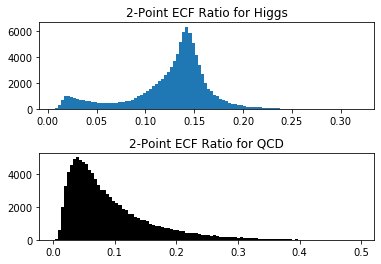

```python
plt.subplots_adjust(hspace = 0.5, wspace = 1)
plt.subplot(2,1,1)
plt.title('2-Point ECF Ratio for Higgs')
plt.hist(higgs_dict['ee2'],100)
plt.subplot(2,1,2)
plt.title('2-Point ECF Ratio for QCD')
plt.hist(qcd_dict['ee2'],100,color='k')
plt.show()
```

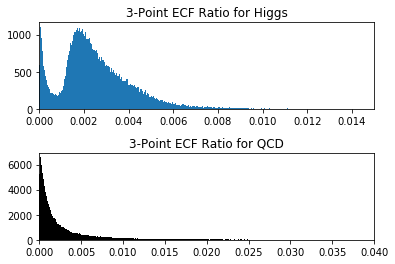

```python
plt.subplots_adjust(hspace = 0.5, wspace = 1)
plt.subplot(2,1,1)
plt.title('3-Point ECF Ratio for Higgs')
plt.hist(higgs_dict['ee3'],1000)
plt.xlim(0,0.015)
plt.subplot(2,1,2)
plt.title('3-Point ECF Ratio for QCD')
plt.hist(qcd_dict['ee3'],1000,color='k')
plt.xlim(0,0.04)
plt.show()
```

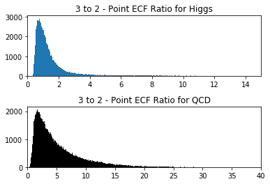

```python
plt.subplots_adjust(hspace = 0.5, wspace = 1)
plt.subplot(2,1,1)
plt.hist(higgs_dict['d2'], 1000)
plt.xlim(0,15)
plt.title('3 to 2 - Point ECF Ratio for Higgs')
plt.subplot(2,1,2)
plt.hist(qcd_dict['d2'], 1000,color='k')
plt.xlim(0,40)
plt.title('3 to 2 - Point ECF Ratio for QCD')
plt.show()
```

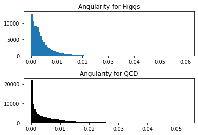

```python
plt.subplots_adjust(hspace = 0.5, wspace = 1)
plt.subplot(2,1,1)
plt.hist(higgs_dict['angularity'], 100)
plt.title('Angularity for Higgs')
plt.subplot(2,1,2)
plt.hist(qcd_dict['angularity'], 100, color='k')
plt.title('Angularity for QCD')
plt.show()
```

# ‘t1’/‘t2’/'t3'/‘t21'/‘t32'

The Higgs boson will decay to bottom quark pair and each of quark form a jet. If the higges boson has large momentumn and two of them has same direction, several quark will combine to one jet. The t1/t2/t3 represents different kinds of N-subjetiness and helps us to indentify what kinds to subjets it is.

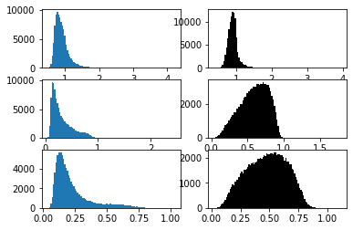

```python
 plt.subplots_adjust(hspace = 2, wspace = 10)
fig, axs = plt.subplots(3, 2)
#axs.figure(figsize=(20, 20))
axs[0,0].hist(higgs_dict['t1'],100)
axs[1,0].hist(higgs_dict['t2'],100)
axs[2,0].hist(higgs_dict['t3'],100)
axs[0,1].hist(qcd_dict['t1'],100,color='k')
axs[1,1].hist(qcd_dict['t2'],100,color='k')
axs[2,1].hist(qcd_dict['t3'],100,color='k')
plt.show()
```

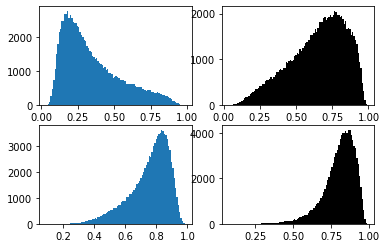

```python
plt.subplots_adjust(hspace = 0.5, wspace = 1)
fig1,axs1 = plt.subplots(2,2)
axs1[0,0].hist(higgs_dict['t21'],100)
axs1[1,0].hist(higgs_dict['t32'],100)
axs1[0,1].hist(qcd_dict['t21'],100,color='k')
axs1[1,1].hist(qcd_dict['t32'],100,color='k')
plt.show()
```

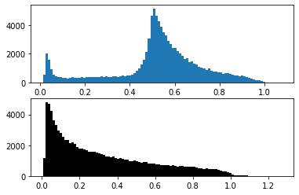

```python
plt.subplot(2,1,1)
plt.hist(higgs_dict['KtDeltaR'],100)
plt.subplot(2,1,2)
plt.hist(qcd_dict['KtDeltaR'],100,color = 'k')
plt.show()
```